# Per-Base Fragment Length Enrichment Analysis: Sarcoma cfDNA

**Assay:** EM-seq cfDNA, hg38 **Run:** `ewing_hg38_v4_20260122` **Date:** 2026-03-05

## Overview

Identify which fragment lengths are significantly enriched in tumor-derived cfDNA using a two-stage per-base resampling framework. Unlike window-based approaches that test pre-defined length ranges, this method evaluates each fragment length independently with its own noise calibration, then lets the data define the enriched region(s).

### Motivation

Mouliere et al. (2018) demonstrated that restricting cfDNA analysis to short fragments (90–150 bp) enriches for tumor-derived DNA and improves CNA sensitivity. However, this window was empirically derived from PDX models and adopted as a fixed heuristic. A prior window-based grid search on our Ewing cohort (see archived notebook) confirmed significant enrichment at 50–110 bp (FWER p < 0.05) but revealed a fundamental enrichment–mass tradeoff that cannot be resolved by testing pre-defined windows. The per-base approach avoids this by characterizing the enrichment landscape across the entire fragment length axis.

### Method

**Stage 1 — Permutation (per-base noise threshold):** For each fragment length (50–450 bp), shuffle cancer/healthy labels 1000 times and compute the enrichment ratio at that specific length. The 95th percentile of the null distribution defines the noise threshold for that length. This naturally accounts for the fact that rare fragment lengths (e.g., 60 bp) have higher sampling variance than common lengths (e.g., 160 bp), producing length-specific thresholds rather than a single global cutoff.

**Stage 2 — Bootstrap (stability):** Keep real labels. Resample patients with replacement 1000 times. At each length, check whether the bootstrapped enrichment exceeds the permutation-derived threshold. Lengths where enrichment exceeds the threshold in ≥95% of bootstrap replicates are classified as stably enriched. Contiguous (or disjoint) enriched regions naturally define the optimal fragment length window(s).

### Sample selection

High-tumor-fraction samples are used as the cancer group to maximize enrichment signal and minimize noise. Samples are selected using two orthogonal metrics:

1. **ichorCNA tumor fraction** from non-size-selected BAMs (CNA-based, independent of fragment length)
2. **Global cfDNA methylation** from tiled EM-seq (hypomethylation indicates tumor signal, independent of fragment length)

Samples scoring high on both metrics are the most confident high-TF set. This avoids circularity — neither metric depends on fragment length, which is the variable being optimized.

### Preprocessing (completed prior to this notebook)

**Fragment length lists (all 111 samples):** Per-sample fragment lengths extracted from filtered BAMs for all 18 healthy + 93 sarcoma samples. Each file contains one integer per line representing the absolute insert size of a properly paired read, filtered to 50–450 bp.

- Location: `{RUN}/meta/fragment_convergence/length_lists_50_450/{sample}.tlen_50_450.txt.gz`
- Extraction: `samtools view -f 66 -F 2304` (proper pair, read1, no secondary/supplementary), awk filter on insert size 50–450
- Fragment counts per sample: ~53M–143M (all exceed N*=500K convergence threshold from prior downsampling analysis)

**Tiled methylation — pan-sarcoma vs healthy (111 samples):** methylKit tiled differential methylation (1 kb windows) run on all 93 sarcoma (tx=1) vs 18 healthy (tx=0) via Snakemake. Used for computing global mean beta per sample.

- Config: `{RUN}/meta/sarcoma_vs_healthy_tiled.yaml`
- Wrapper: `{RUN}/workflows/wrapper_methyl_only.smk`
- methylBase output: `{RUN}/emseq/dmr/diff/methylBase_sarcoma_vs_healthy.tiled.txt.bgz`
- methylDiff output: `{RUN}/emseq/dmr/diff/methylDiff_sarcoma_vs_healthy.tiled.txt.bgz`

**ichorCNA tumor fraction — non-size-selected (all samples):** ichorCNA run on unfiltered BAMs (1 Mb bins, custom PoN, low tumor mode). Provides CNA-based tumor fraction estimates independent of fragment length.

- Run: `run_20260216_1Mb_baseline_filt_lowtumor_noES108`
- TF file: `/mnt/data/scripts/ichorCNA/scripts/snakemake/runs_custom_PoN/run_20260216_1Mb_baseline_filt_lowtumor_noES108/post_analysis/tf.txt`
- Merged with groups: `.../roc/comparisons/ALL_TUMOR_vs_HEALTHY.tsv` (columns: sample, group, tf, label)

## 1. Setup and sample selection

```r
suppressPackageStartupMessages({
  library(data.table)
  library(ggplot2)
})
.libPaths(c("~/R_libs", .libPaths()))
library(patchwork)

RUN    <- "/mnt/data/ewing2/emseq_v4_runs/ewing_hg38_v4_20260122"
LENDIR <- file.path(RUN, "meta/fragment_convergence/length_lists_50_450")
LO <- 50
HI <- 450
BINS <- LO:HI

# Sample metadata
meta <- fread("/mnt/data/ewing/meta/library_to_group.cleaned.tsv",
              header = FALSE, col.names = c("sample", "subtype"))
meta <- meta[sample != "ES108"]

cat("Total samples:", nrow(meta), "\n")
cat("Healthy:", meta[subtype == "healthy", .N], "\n")
cat("Sarcoma:", meta[subtype != "healthy", .N], "\n")
```

```
Total samples: 111
Healthy: 18
Sarcoma: 93
```

### 1a. Load tumor signal metrics

Two orthogonal metrics are used to identify samples with tumor-derived cfDNA:

1. **ichorCNA tumor fraction** (CNA-based, from non-size-selected BAMs)
2. **Global cfDNA methylation** (from tiled EM-seq, pan-sarcoma vs healthy)

Neither metric depends on fragment length, avoiding circularity with the variable being optimized.

```r
# ichorCNA TF (1Mb bins, custom PoN, low tumor mode, non-size-selected)
ichor <- fread("/mnt/data/scripts/ichorCNA/scripts/snakemake/runs_custom_PoN/run_20260216_1Mb_baseline_filt_lowtumor_noES108/roc/comparisons/ALL_TUMOR_vs_HEALTHY.tsv")

# Global methylation from pan-sarcoma tiled methylBase
mbase_file <- file.path(RUN, "emseq/dmr/diff/methylBase_sarcoma_vs_healthy.tiled.txt.bgz")
dt <- fread(cmd = paste("zcat", mbase_file, "| grep -v '^#'"), header = FALSE)

healthy_ids <- meta[subtype == "healthy", sample]
sarcoma_ids <- meta[subtype != "healthy", sample]
sample_order <- c(healthy_ids, sarcoma_ids)

# Assign column names: chr, start, end, strand, then (cov, numCs, numTs) per sample
base_cols <- c("chr", "start", "end", "strand")
sample_cols <- unlist(lapply(sample_order, function(s) paste0(s, c(".cov", ".numCs", ".numTs"))))
colnames(dt) <- c(base_cols, sample_cols)

# Compute global mean beta per sample
global_beta <- data.table(sample = sample_order)
global_beta[, beta := sapply(sample, function(s) {
  cs <- dt[[paste0(s, ".numCs")]]
  ts <- dt[[paste0(s, ".numTs")]]
  cov <- cs + ts
  keep <- !is.na(cov) & cov >= 10
  sum(cs[keep]) / sum(cov[keep])
})]
global_beta <- merge(global_beta, meta, by = "sample")

# Z-score against healthy
h_mean <- global_beta[subtype == "healthy", mean(beta)]
h_sd   <- global_beta[subtype == "healthy", sd(beta)]
global_beta[, z := (beta - h_mean) / h_sd]

# Merge with ichorCNA
combined <- merge(global_beta, ichor[, .(sample, tf)], by = "sample", all.x = TRUE)
combined[is.na(tf), tf := 0]

cat("Samples with both metrics:", nrow(combined), "\n")
```

```
Samples with both metrics: 111
```

### 1b. Sample selection

**Criteria:**

*Healthy group:* Exclude ES102 (methylation z = −1.98, outside 95% CI of healthy distribution). Remaining n = 17.

*Cancer group:* Include any sarcoma sample meeting at least one of:

- ichorCNA TF > 0.02 (well above healthy maximum of 0.013)
- Global methylation z < −1.96 (outside 95% CI of healthy distribution)

Both thresholds are defined relative to the healthy distribution, ensuring every selected cancer sample shows tumor signal that no healthy sample exhibits.

```r
# Apply selection criteria
selected_healthy <- combined[subtype == "healthy" & sample != "ES102", sample]
selected_cancer  <- combined[subtype != "healthy" & (tf > 0.02 | z < -1.96), sample]

cat("Healthy group:", length(selected_healthy), "\n")
cat("Cancer group:", length(selected_cancer), "\n")
cat("Total:", length(selected_healthy) + length(selected_cancer), "\n\n")

cat("Cancer group by subtype:\n")
print(combined[sample %in% selected_cancer, .N, by = subtype][order(-N)])

cat("\nCancer group by selection criterion:\n")
print(combined[sample %in% selected_cancer, .(
  sample, subtype, tf = round(tf, 4), z = round(z, 2),
  criterion = fifelse(tf > 0.02 & z < -1.96, "both",
               fifelse(tf > 0.02, "TF", "methylation"))
)][order(z)])
```

```
Healthy group: 17
Cancer group: 28
Total: 45

Cancer group by subtype:
            subtype     N
             <char> <int>
1:    ewing_sarcoma    14
2: rhabdomyosarcoma     6
3: synovial_sarcoma     2
4:         chordoma     2
5:   chondrosarcoma     2
6:      liposarcoma     1
7:     osteosarcoma     1

```

[output cut: 32 more lines]

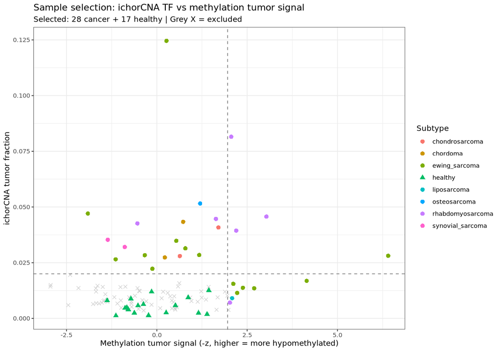

```r
options(repr.plot.width = 10, repr.plot.height = 7)

# Map shapes per subtype directly
subtype_shapes <- c("chondrosarcoma" = 16, "chordoma" = 16, "ewing_sarcoma" = 16,
                     "fibrosarcoma" = 16, "healthy" = 17, "liposarcoma" = 16,
                     "osteosarcoma" = 16, "rhabdomyosarcoma" = 16, "synovial_sarcoma" = 16)

ggplot(combined[selected != "excluded"],
       aes(x = -z, y = tf, color = subtype, shape = subtype)) +
  geom_point(data = combined[selected == "excluded"], aes(x = -z, y = tf),
             color = "grey80", shape = 4, size = 2, inherit.aes = FALSE) +
  geom_point(size = 2.5) +
  geom_vline(xintercept = 1.96, linetype = "dashed", color = "grey50") +
  geom_hline(yintercept = 0.02, linetype = "dashed", color = "grey50") +
  scale_shape_manual(values = subtype_shapes) +
  theme_bw() +
  labs(
    title = "Sample selection: ichorCNA TF vs methylation tumor signal",
    subtitle = paste0("Selected: ", length(selected_cancer), " cancer + ",
                      length(selected_healthy), " healthy | Grey X = excluded"),
    x = "Methylation tumor signal (-z, higher = more hypomethylated)",
    y = "ichorCNA tumor fraction",
    color = "Subtype", shape = "Subtype"
  )
```

## 2. Load fragment length distributions

```r
load_fragdist <- function(sample_id, lendir, lo, hi) {
  f <- file.path(lendir, paste0(sample_id, ".tlen_50_450.txt.gz"))
  if (!file.exists(f)) { warning(paste("Missing:", f)); return(NULL) }
  lengths <- scan(gzfile(f), what = integer(), quiet = TRUE)
  counts  <- tabulate(lengths - lo + 1, nbins = hi - lo + 1)
  total   <- sum(counts)
  prob    <- counts / total
  list(counts = counts, total = total, prob = prob)
}

all_dists <- list()
for (s in c(selected_cancer, selected_healthy)) {
  d <- load_fragdist(s, LENDIR, LO, HI)
  if (!is.null(d)) all_dists[[s]] <- d
}

cat("Loaded:", length(all_dists), "samples\n")
cat("Cancer:", sum(names(all_dists) %in% selected_cancer), "\n")
cat("Healthy:", sum(names(all_dists) %in% selected_healthy), "\n")
```

```
Loaded: 45 samples
Cancer: 28
Healthy: 17
```

## 3. Observed enrichment curve

```
Enrichment range: 0.847 3.818
Max enrichment: 3.818 at 60 bp
```

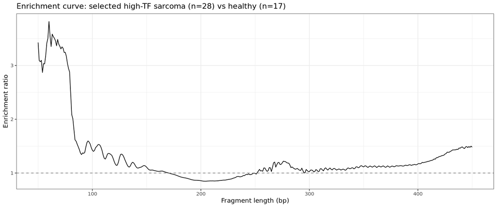

```r
cancer_probs  <- do.call(rbind, lapply(selected_cancer[selected_cancer %in% names(all_dists)],
                                        function(s) all_dists[[s]]$prob))
healthy_probs <- do.call(rbind, lapply(selected_healthy[selected_healthy %in% names(all_dists)],
                                        function(s) all_dists[[s]]$prob))

p_cancer  <- colMeans(cancer_probs)
p_healthy <- colMeans(healthy_probs)

eps <- 1e-8
enrichment <- p_cancer / (p_healthy + eps)

cat("Enrichment range:", round(range(enrichment), 3), "\n")
cat("Max enrichment:", round(max(enrichment), 3), "at", BINS[which.max(enrichment)], "bp\n")

options(repr.plot.width = 12, repr.plot.height = 5)

enrich_dt <- data.table(length = BINS, enrichment = enrichment)
ggplot(enrich_dt, aes(x = length, y = enrichment)) +
  geom_line(linewidth = 0.5) +
  geom_hline(yintercept = 1, linetype = "dashed", color = "grey50") +
  theme_bw() +
  labs(title = "Enrichment curve: selected high-TF sarcoma (n=28) vs healthy (n=17)",
       x = "Fragment length (bp)", y = "Enrichment ratio")
```

## 4. Per-base permutation testing

For each fragment length independently, shuffle cancer/healthy labels 1000 times and compute the enrichment ratio. The 95th percentile of the null distribution at each length defines a length-specific noise threshold. This accounts for the fact that rare fragment lengths (tails) are inherently noisier than common lengths (mononucleosomal peak).

```r
set.seed(42)
n_perm <- 1000

all_samples <- c(selected_cancer[selected_cancer %in% names(all_dists)],
                 selected_healthy[selected_healthy %in% names(all_dists)])
all_probs   <- do.call(rbind, lapply(all_samples, function(s) all_dists[[s]]$prob))
rownames(all_probs) <- all_samples

n_cancer  <- sum(all_samples %in% selected_cancer)
n_healthy <- sum(all_samples %in% selected_healthy)
n_total   <- n_cancer + n_healthy
n_bins    <- length(BINS)

cat("Samples:", n_cancer, "cancer,", n_healthy, "healthy,", n_total, "total\n")
cat("Bins:", n_bins, "\n")
cat("Permutations:", n_perm, "\n\n")

# Per-base null distributions
null_enrich <- matrix(NA_real_, nrow = n_perm, ncol = n_bins)

for (i in seq_len(n_perm)) {
  perm_idx <- sample(n_total)
  pe <- colMeans(all_probs[perm_idx[1:n_cancer], , drop = FALSE])
  ph <- colMeans(all_probs[perm_idx[(n_cancer+1):n_total], , drop = FALSE])
  null_enrich[i, ] <- pe / (ph + eps)
  if (i %% 200 == 0) cat("  perm", i, "/", n_perm, "\n")
}

# Per-base 95th percentile threshold
thresh_95 <- apply(null_enrich, 2, function(x) quantile(x, 0.95))

cat("\nThreshold range:", round(range(thresh_95), 3), "\n")
cat("Threshold at 68 bp:", round(thresh_95[68 - LO + 1], 3), "\n")
cat("Threshold at 150 bp:", round(thresh_95[150 - LO + 1], 3), "\n")

# Which bins exceed their per-base threshold?
sig_bins <- BINS[enrichment > thresh_95]
cat("\nBins exceeding per-base 95th percentile:", length(sig_bins), "\n")
if (length(sig_bins) > 0) cat("Range:", min(sig_bins), "-", max(sig_bins), "bp\n")
```

```
Samples: 28 cancer, 17 healthy, 45 total
Bins: 401
Permutations: 1000

  perm 200 / 1000
  perm 400 / 1000
  perm 600 / 1000
  perm 800 / 1000
  perm 1000 / 1000

Threshold range: 1.071 3.477
Threshold at 68 bp: 2.677
Threshold at 150 bp: 1.151

Bins exceeding per-base 95th percentile: 51
Range: 58 - 129 bp
```

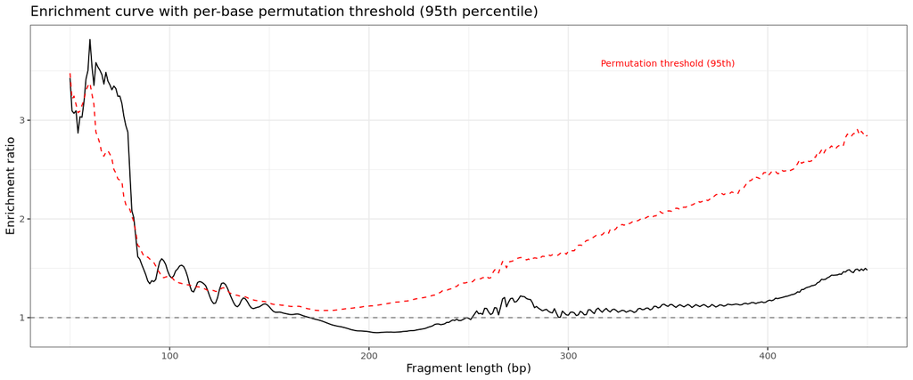

```r
options(repr.plot.width = 12, repr.plot.height = 5)

thresh_dt <- data.table(length = BINS, threshold = thresh_95)

ggplot() +
  geom_line(data = enrich_dt, aes(x = length, y = enrichment), linewidth = 0.5) +
  geom_line(data = thresh_dt, aes(x = length, y = threshold),
            color = "red", linetype = "dashed", linewidth = 0.5) +
  geom_hline(yintercept = 1, linetype = "dashed", color = "grey50") +
  theme_bw() +
  labs(
    title = "Enrichment curve with per-base permutation threshold (95th percentile)",
    x = "Fragment length (bp)",
    y = "Enrichment ratio"
  ) +
  annotate("text", x = 350, y = max(thresh_95) + 0.1, label = "Permutation threshold (95th)",
           color = "red", size = 3)
```

## 5. Per-base bootstrap stability

For each fragment length, resample patients with replacement 1000 times (within real groups). At each length, check whether the bootstrapped enrichment exceeds the permutation threshold for that length. Stability = fraction of bootstraps exceeding threshold. Lengths with stability ≥ 0.95 are classified as stably enriched.

```r
set.seed(123)
n_boot <- 1000

cancer_idx  <- which(all_samples %in% selected_cancer)
healthy_idx <- which(all_samples %in% selected_healthy)

# Bootstrap: per-base stability
boot_pass <- matrix(FALSE, nrow = n_boot, ncol = n_bins)

for (b in seq_len(n_boot)) {
  bc <- sample(cancer_idx, replace = TRUE)
  bh <- sample(healthy_idx, replace = TRUE)

  pe <- colMeans(all_probs[bc, , drop = FALSE])
  ph <- colMeans(all_probs[bh, , drop = FALSE])
  boot_enrich <- pe / (ph + eps)

  boot_pass[b, ] <- boot_enrich > thresh_95
  if (b %% 200 == 0) cat("  boot", b, "/", n_boot, "\n")
}

stability <- colMeans(boot_pass)

cat("\nStability range:", round(range(stability), 3), "\n")
cat("Bins with stability >= 0.95:", sum(stability >= 0.95), "\n")
cat("Bins with stability >= 0.90:", sum(stability >= 0.90), "\n")
cat("Bins with stability >= 0.80:", sum(stability >= 0.80), "\n")

stable_bins <- BINS[stability >= 0.95]
if (length(stable_bins) > 0) {
  cat("\nStably enriched region (stability >= 0.95):", min(stable_bins), "-", max(stable_bins), "bp\n")

  # Check for gaps
  gaps <- which(diff(stable_bins) > 1)
  if (length(gaps) == 0) {
    cat("Contiguous window:", min(stable_bins), "-", max(stable_bins), "bp\n")
  } else {
    starts <- c(stable_bins[1], stable_bins[gaps + 1])
    ends   <- c(stable_bins[gaps], stable_bins[length(stable_bins)])
    cat("Disjoint windows:\n")
    for (j in seq_along(starts)) cat("  ", starts[j], "-", ends[j], "bp\n")
  }
}
```

```
  boot 200 / 1000
  boot 400 / 1000
  boot 600 / 1000
  boot 800 / 1000
  boot 1000 / 1000

Stability range: 0 0.844
Bins with stability >= 0.95: 0
Bins with stability >= 0.90: 0
Bins with stability >= 0.80: 4
```

## 6. Results summary

### Permutation

51 fragment lengths (58–129 bp) exceed their per-base 95th percentile permutation threshold, confirming significant tumor-derived enrichment in this range.

### Bootstrap

No individual fragment length achieves ≥ 0.95 stability (max = 0.84). This reflects tumor fraction heterogeneity across the cohort — the enrichment is real but its magnitude at any given base pair varies depending on which samples are included. This is consistent with the known variability in cfDNA tumor fraction across patients.

```r
# Redefine groups: all sarcoma vs healthy (minus ES102)
selected_cancer_all  <- meta[subtype != "healthy", sample]
selected_healthy_all <- meta[subtype == "healthy" & sample != "ES102", sample]

# Load all distributions
all_dists_full <- list()
for (s in c(selected_cancer_all, selected_healthy_all)) {
  d <- load_fragdist(s, LENDIR, LO, HI)
  if (!is.null(d)) all_dists_full[[s]] <- d
}

cat("Loaded:", length(all_dists_full), "\n")
cat("Cancer:", sum(names(all_dists_full) %in% selected_cancer_all), "\n")
cat("Healthy:", sum(names(all_dists_full) %in% selected_healthy_all), "\n")
```

```
Loaded: 110
Cancer: 93
Healthy: 17
```